# PARADA CARDIORESPIRATÓRIA ROTINAS HRT LUIZ ANTÔNIO

Parada cardiorrespiratória

Introdução

Esta rotina aborda ressuscitação cardiopulmonar em pediatria em ambiente hospitalar. É baseada nas diretrizes de 2020, do International Liaison Committee on Resuscitation (ILCOR), constituída pelos principais comitês de ressuscitação do mundo. Envolve um conjunto de medidas que visam restabelecer a função respiratória e circulatória e estão indicadas na parada cardiorrespiratória e na bradicardia com sinais de hipoperfusão.

Definição

Entende-se por parada cardiorrespiratória (PCR) a ausência de pulso, a apneia ou gasping e a ausência de responsividade. Ocorre a interrupção da circulação sanguínea como resultado da ausência ou ineficácia da atividade mecânica cardíaca.

Causa

Enquanto a PCR em adultos ocorre de maneira súbita, geralmente relacionada à fibrilação ou taquicardia ventricular, em crianças ocorre mais frequentemente por hipóxia relacionada a uma piora respiratória ou cardiocirculatória progressiva, portanto, esteja atento às situações de baixa oxigenação, ventilação e a perfusão tecidual inadequadas.

Taxa de sobrevida

Variável de acordo com o local. Se ocorrer em ambiente hospitalar está em torno de 43% e extra-hospitalar de 8%. Também será mais alta se o ritmo for chocável – 25% a 34% e de 7% a 24% se for assistolia.

Como proceder

A avaliação, diagnóstico e conduta deve começar em no máximo 10 segundos. A criança em PCR se apresentará sem responsividade, ou seja, sem contactuar, sem resposta verbal e sem resposta a dor. Estará em apneia ou em gasping; não apresentará movimento respiratório ou se este existir, não será suficiente para a captação de oxigênio; a avaliação é por inspeção. Os pulsos estarão ausentes, tanto os centrais quanto os periféricos e a checagem se dão pela palpação dos principais pontos: braquial para os menores de 1 ano e carotídeo para os maiores de 1 ano e femoral e radial para todas as idades. Outros pulsos poderão ser checados. Estes três valores são suficientes para o diagnóstico de uma PCR (sem responsividade, apneia ou gasping e sem pulso palpável). Imediatamente, inicia-se a RCP de alta qualidade que se baseia em manobras que serão descritas logo a seguir e de ações auxiliares, como a monitorização contínua, a instalação de oxigênio, acesso vascular e glicemia capilar. As medicações e eletroterapia devem ser concomitantes de acordo com a necessidade de cada caso.

A assistência adequada, em ambiente hospitalar, começa com uma boa equipe formada por profissionais que tenham experiência e domínio das habilidades de ressuscitação, bem como uma boa dinâmica e comunicação. É importante ter funções definidas, responsabilidades claras, conhecer as limitações de cada um, compartilhar conhecimentos, intervenção construtiva e respeito mútuo.

Disposição dos socorristas

[figure not shown]

Funções e responsabilidades

[output not shown]

A RCP de alta qualidade se baseia em compressões torácicas e ventilações. A sequência recomendada nas diretrizes atuais, começa com compressões, depois abertura de vias aéreas e ventilação. As compressões devem ser fortes o suficiente para pressionar o tórax no terço inferior do esterno, aproximadamente 4 a 5 cm de profundidade, permitir o retorno torácico por completo para que haja retorno venoso; numa frequência entre 100 e 120 compressões por minuto, deve-se minimizar ao máximo as interrupções e evitar ventilações excessivas, pois isso pode ser prejudicial porque impede o retorno venoso e diminui e débito cardíaco. As ventilações precisam ser seguras e adequadas – a elevação do tórax deve ser observada. A ventilação com bolsa-valva-máscara é tão eficaz quanto a intubação, não se deve perder tempo tentando intubar se há dificuldade. A relação compressão-ventilação pode variar de acordo com o número de socorrista; quando há apenas 1 socorrista, executa-se 30:2 (30 compressões para 2 ventilações) e quando há 2 socorristas, a proporção é 15:2 (15 compressões para 2 ventilações). Caso o paciente esteja intubado a relação compressão-ventilação não existe, enquanto 1 faz compressões entre 100 a 120 por minuto, o outro faz 1 ventilação a cada 2 a 3 segundos. A cada dois minutos ou menos se houver cansaço, os socorristas deverão se revezar nas compressões e o tempo de troca deverá ser o mínimo possível.

A ressuscitação cardiopulmonar (RCP) não encerra o tratamento curativo, mas um meio que permite a perfusão tecidual adequada até que a causa desencadeante seja controlada. O controle e estabilização do paciente são fundamentais para que possamos dar condições de remoção até uma unidade de terapia intensiva.

Taquicardia ventricular sem pulso Fibrilação ventricular

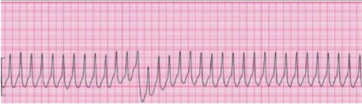

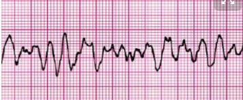

Assistolia Atividade elétrica sem pulso

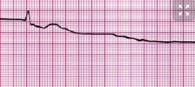

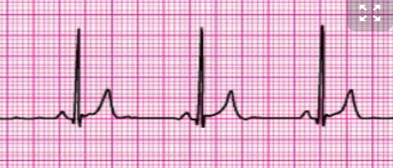

Tamanho das pás: infantis para menores de 1 ano ou 10 kg e tipo adulto para os maiores.

Atividade elétrica sem pulso

Trate a causa

Algumas drogas:

Adrenalina: 0,01 mg/kg (0,1 ml/kg solução 1:10000) IV ou IO a cada 3 a 5 minutos;

Atropina: 0,02 mg/kg (max 0,5 mg em crianças e 1 g em adolescentes) – bloqueio e atividade vagal;

Amiodarona: 5 mg/kg – pode ser repetida até 2x;

Lidocaína: 1 mg/kg

Importante: sugerimos a realização de cursos avançados que envolvem as PCRs a fim de que enriqueça mais os conhecimentos e habilidades e multiplique o aprendizado para que cada vez mais as nossas crianças tenham recuperação com o mínimo de sequela possível.

Referências

1. http://www.bombeiros.pr.gov.br/arquivos/File/1gb/socorros/Viasaereas.pdf
2. American Heart Association, Suporte Avançado de vida em Pediatria. Manual do profissional, Orora visual, 3210 Innovative Way, Mesquite, Texas, EUA, edição em português, 2020;
3. Condutas pediátricas no pronto atendimento e na terapia intensiva / editoras Luciana Rodrigues Silva, Luanda Flores da Costa, 2. ed, Santana de Parnaíaba, SP, Editora Manole, 2020.
4. Pronto-socorro / coordenadores Claudio Schvartsman, Amélia Gorete Reis, Sylvia Costa Lima Farat, 4. ed, Barueri, SP, Editora Manole,2023.
5. Urgências e Emergências Pediátricas, manual para rápida tomada de decisão / Adriana Pasmanik Eisencraft, Sylvia Costa Lima farah. - 1 ed, Rio de Janeiro, Editora Guanabara Koogan, 2021.

Responsável pela revisão e atualização: Dr Luiz Antonio Silva, CRMDF 6638, RQE 20151, Emergencista pediatra.